# assignment_1

2022-11-23

## We would like to look at the unconditional income difference bewteen men and female Lawyers, Judges, magistrates, and other judicial workers (occ2012 = 2100)

```
## # A tibble: 3 × 3
##     sex mean_earning numObs
##   <dbl>        <dbl>  <int>
## 1     1        2003.    619
## 2     2        1706.    408
## 3    NA        -298.   1027
```

We can see that the difference in unconditional weekly gender pay gap between men and women is $298 on average in 1027 observations.

## Gender pay gap with education difference

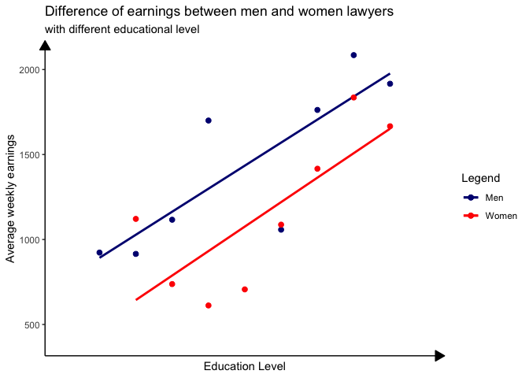

From the regression line, we can see that Men Lawyers have higher earnings than Women Lawyers on all the education levels, while the average earning of both genders tend to increase with higher education qualification.

## Correlation Coefficient between educational level and average earnings of men and women lawyers

Correlation Coefficient between educational level and average earnings of men lawyers

```r
cor(diff_edu$grade92, diff_edu$mean_earning_m)
```

```
## [1] 0.7842544
```

Correlation Coefficient between educational level and average earnings of women lawyers

```r
cor(diff_edu$grade92, diff_edu$mean_earning_wm)
```

```
## [1] 0.8041692
```

## Regression Coefficients

β0 and β1 of men lawyers earnings dependent on their education level

```r
lm(diff_edu$mean_earning_m ~ diff_edu$grade92)
```

```
##
## Call:
## lm(formula = diff_edu$mean_earning_m ~ diff_edu$grade92)
##
## Coefficients:
##      (Intercept)  diff_edu$grade92
##          -4406.1             138.9
```

Standard Error of sample with the regression value of men lawyers earnings dependent on their education level

```r
std.error(diff_edu$mean_earning_m)
```

```
## [1] 176.5226
```

β0 and β1 of women lawyers earnings dependent on their education level

```r
lm(diff_edu$mean_earning_wm ~ diff_edu$grade92)
```

```
##
## Call:
## lm(formula = diff_edu$mean_earning_wm ~ diff_edu$grade92)
##
## Coefficients:
##      (Intercept)  diff_edu$grade92
##            -4705               139
```

Standard Error of sample with the regression value of women lawyers earnings dependent on their education level

```r
std.error(diff_edu$mean_earning_wm)
```

```
## [1] 172.2172
```